# Physical Measures

jdt

2023-09-20

## Background

Larner (1996) measured the weight and various physical measurements for 22 males aged 16–30.  
Subjects were randomly chosen volunteers and all were in reasonably good health.  
Subjects were requested to tense each muscle being measured slightly to ensure measurement consistency.  
The question of interest for these data is how weight can best be predicted from the other measurements.

## Dataset

```r
library(readxl)
PhysicalMeasures <- read_xlsx(file.path("physicalmeasures.xlsx"))
summary(PhysicalMeasures)
```

```
##       Mass            Fore           Bicep           Chest
##  Min.   :54.50   Min.   :24.00   Min.   :28.50   Min.   : 87.50
##  1st Qu.:66.00   1st Qu.:26.50   1st Qu.:31.00   1st Qu.: 94.25
##  Median :73.00   Median :28.25   Median :33.50   Median : 99.50
##  Mean   :73.93   Mean   :27.77   Mean   :33.20   Mean   : 99.64
##  3rd Qu.:80.38   3rd Qu.:29.38   3rd Qu.:35.88   3rd Qu.:105.50
##  Max.   :94.00   Max.   :31.00   Max.   :38.00   Max.   :112.00
##       Neck          Shoulder         Waist            Height
##  Min.   :35.00   Min.   :102.0   Min.   : 74.00   Min.   :168.5
##  1st Qu.:35.75   1st Qu.:105.8   1st Qu.: 80.62   1st Qu.:173.2
##  Median :38.50   Median :113.5   Median : 84.00   Median :178.8
##  Mean   :37.59   Mean   :111.8   Mean   : 85.57   Mean   :178.5
##  3rd Qu.:39.00   3rd Qu.:117.8   3rd Qu.: 91.25   3rd Qu.:182.9
##  Max.   :40.50   Max.   :121.0   Max.   :101.00   Max.   :188.0
##       Calf           Thigh            Head
##  Min.   :32.00   Min.   :42.00   Min.   :55.50
##  1st Qu.:36.00   1st Qu.:49.00   1st Qu.:57.00
##  Median :38.00   Median :49.75   Median :58.00
##  Mean   :37.34   Mean   :49.73   Mean   :58.07
##  3rd Qu.:38.88   3rd Qu.:51.75   3rd Qu.:59.00
##  Max.   :42.00   Max.   :57.50   Max.   :60.00
```

## Scatterplot Matrix

```r
library(GGally)
ggpairs(PhysicalMeasures, axisLabels = "none",
        title = "Scatterplot Matrix of Physical Measures")
```

```r
# corr codes
```

## Scatterplot Matrix

[figure not shown]

## Linear Model of Mass with Forearm as the Predictor

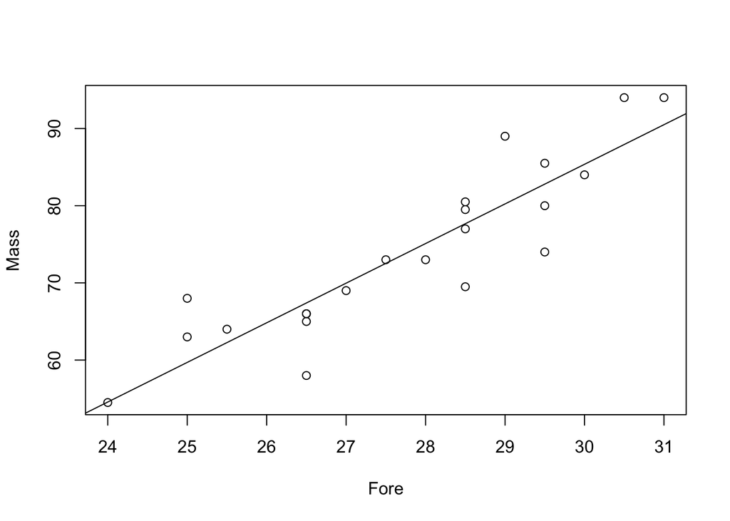

```r
#waist=Physicalmeasures$Waist

fit_fore <- lm(Mass ~ Fore, data = PhysicalMeasures)
summary(fit_fore) # does not have VIFs included like SAS
plot(Mass ~ Fore, data = PhysicalMeasures)
abline(fit_fore)
```

## Checking Regression Assumptions

Linear regression makes several assumptions about the data, such as :  
1) Linearity of the data: The relationship between the predictor (x) and the outcome (y) is assumed to be linear.  
2) Normality of residuals: The residual errors are assumed to be normally distributed.  
3) Homogeneity of residuals variance: The residuals are assumed to have a constant variance (homoscedasticity).  
4) Independence of residuals error terms.  
You should check whether or not these assumptions hold true.

## Fit Diagnostics – Predicted Means

```r
fitted(fit_fore) # predicted values
```

```
##        1        2        3        4        5        6        7        8
## 77.66539 82.79906 59.69756 77.66539 77.66539 87.93273 67.39806 69.96489
##        9       10       11       12       13       14       15       16
## 67.39806 67.39806 77.66539 72.53173 82.79906 59.69756 82.79906 67.39806
##       17       18       19       20       21       22
## 54.56390 62.26439 85.36589 75.09856 80.23223 90.49956
```

## Fit Diagnostics – Residuals

```r
residuals(fit_fore) # residuals
```

```
##           1           2           3           4           5           6
## -0.66539365  2.70094007  3.30243831  2.83460635  1.83460635  6.06727380
##           7           8           9          10          11          12
## -1.39806110 -0.96489424 -2.39806110 -9.39806110 -8.16539365  0.46827262
##          13          14          15          16          17          18
## -8.79905993  8.30243831 -2.79905993 -1.39806110 -0.06389542  1.73560517
##          19          20          21          22
## -1.36589307 -2.09856052  8.76777321  3.50044066
```

## Fit Diagnostics – ANOVA Table

```r
summary(fit_fore)
```

```
##
## Call:
## lm(formula = Mass ~ Fore, data = PhysicalMeasures)
##
## Residuals:
##     Min      1Q  Median      3Q     Max
## -9.3981 -1.9234 -0.3646  2.8012  8.7678
##
## Coefficients:
##             Estimate Std. Error t value Pr(>|t|)
## (Intercept)  -68.644     15.589  -4.403 0.000274 ***
## Fore           5.134      0.560   9.167 1.34e-08 ***
## ---
## Signif. codes:  0 '***' 0.001 '**' 0.01 '*' 0.05 '.' 0.1 ' ' 1
##
## Residual standard error: 4.926 on 20 degrees of freedom
## Multiple R-squared:  0.8078, Adjusted R-squared:  0.7981
## F-statistic: 84.03 on 1 and 20 DF,  p-value: 1.338e-08
```

```r
summary.aov(fit_fore)
```

```
##             Df Sum Sq Mean Sq F value   Pr(>F)
## Fore         1 2038.9  2038.9   84.03 1.34e-08 ***
## Residuals   20  485.3    24.3
## ---
## Signif. codes:  0 '***' 0.001 '**' 0.01 '*' 0.05 '.' 0.1 ' ' 1
```

All these assumptions and potential problems can be checked by producing some diagnostic plots visualizing the residual errors.

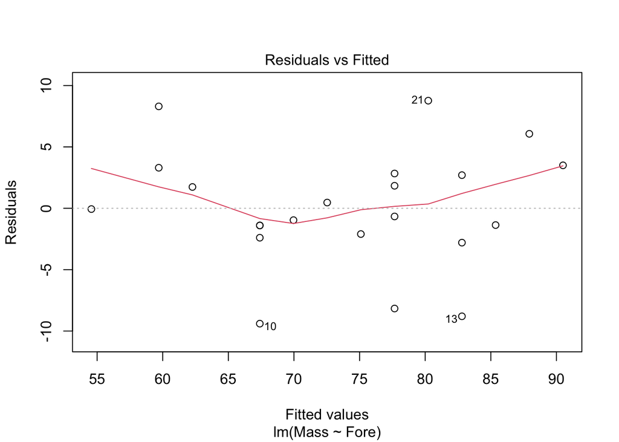

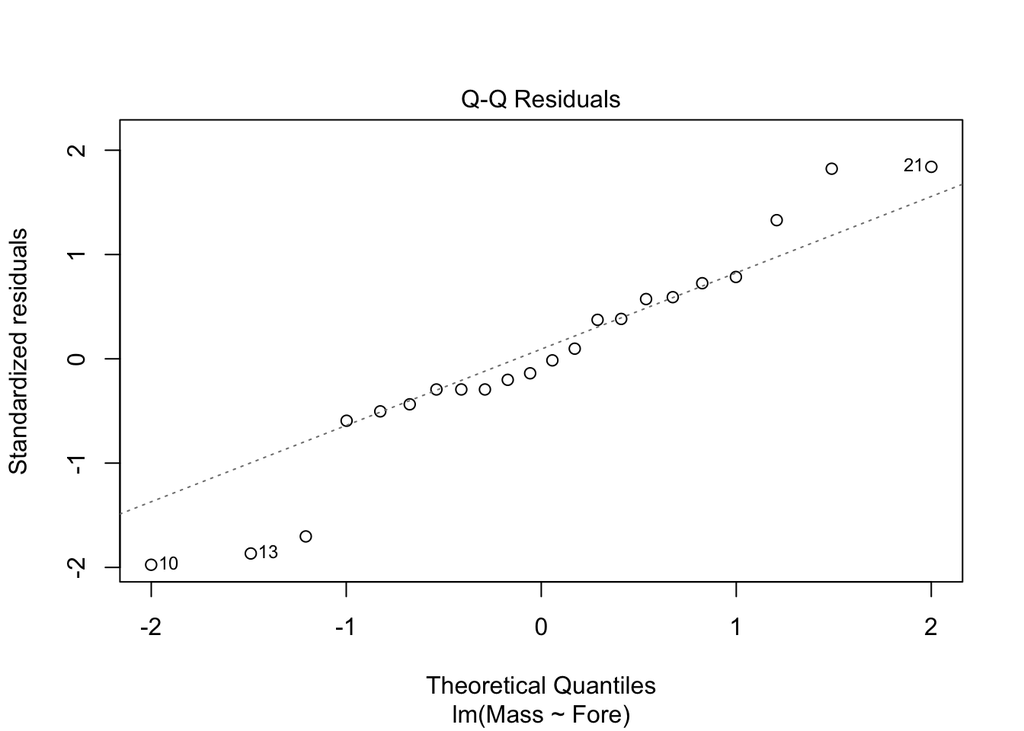

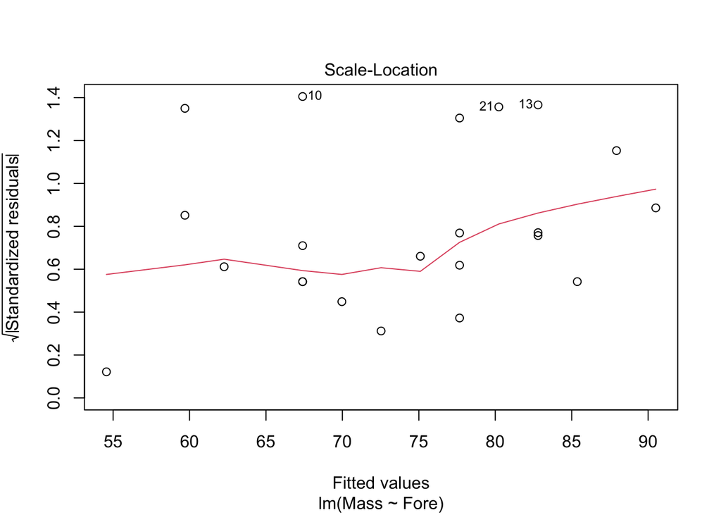

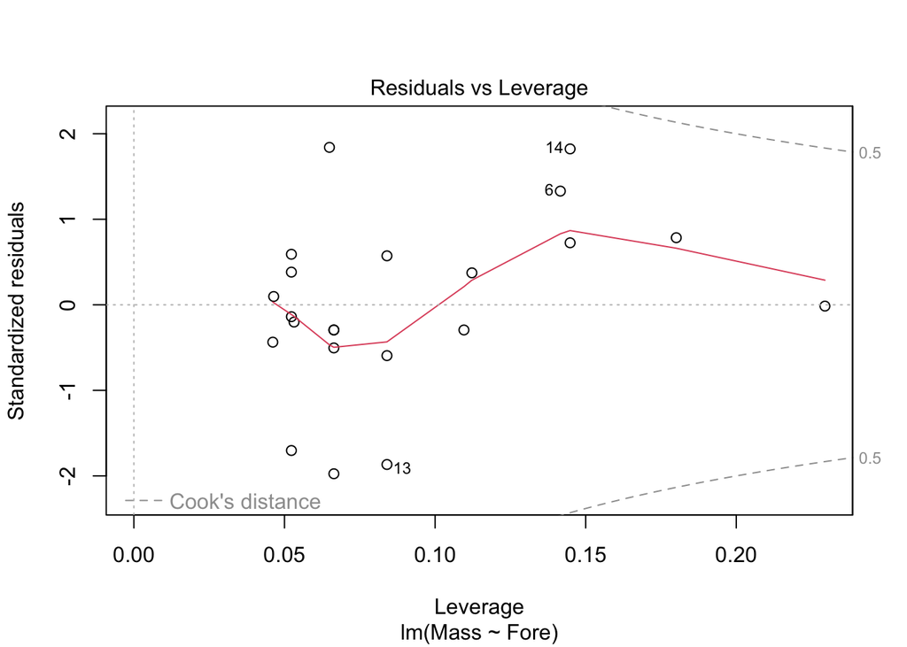

```r
plot(fit_fore)
```

## Potential Problems

1. Non-linearity of the outcome - predictor relationships
2. Heteroscedasticity: Non-constant variance of error terms.
3. Presence of influential values in the data that can be:  
   -Outliers: extreme values in the outcome (y) variable  
   -High-leverage points: extreme values in the predictors (x) variable